# Project I

Avisek Choudhury Pierre Cobb

6/3/2019

# General Description of JSON File

JSON [Java Script Object Notation] and XML [eXtensible Markup Language] are both popular choices to exchange data between 2 systems over the interenet or in general. JSON is easy for machines to parse and generate. It is based on a subset of the JavaScript Programming Language. JSON is a text format that is completely language independent but uses conventions that are familiar to programmers of the C-family of languages, including C, C++, C#, Java, JavaScript, Perl, Python, and many others. These properties make JSON an ideal data-interchange language. JSON is becoming more and more popular these days as it’s compact, lightweight and easy to use and easy for humans to read and write. JSON uses a map data structure rather than XML’s tree. In some situations, key/value pairs can limit what you can do, but you get a predictable and easy-to-understand data model.

JSON is built on two structures:

- A collection of name/value pairs. In various languages, this is realized as an object, record, struct, dictionary, hash table, keyed list, or associative array
- An ordered list of values. In most languages, this is realized as an array, vector, list, or sequence

These are universal data structures. Virtually all modern programming languages support them in one form or another. It makes sense that a data format that is interchangeable with programming languages also be based on these structures.

In JSON, they take on these forms:

An object is an unordered set of name/value pairs. An object begins with `{`left brace and ends with `}` right brace. Each name is followed by :colon and the name/value pairs are separated by ,comma.

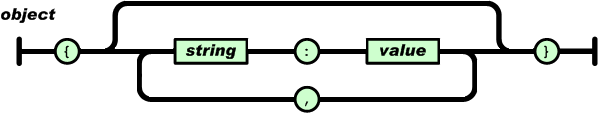

An array is an ordered collection of values. An array begins with [left bracket and ends with ]right bracket. Values are separated by ,comma.

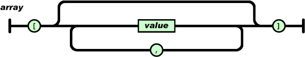

A value can be a string in double quotes, or a number, or true or false or null, or an object or an array. These structures can be nested.

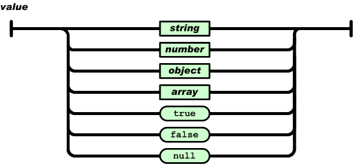

A string is a sequence of zero or more Unicode characters, wrapped in double quotes, using backslash escapes. A character is represented as a single character string. A string is very much like a C or Java string.

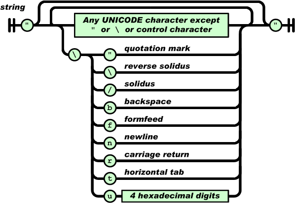

A number is very much like a C or Java number, except that the octal and hexadecimal formats are not used.

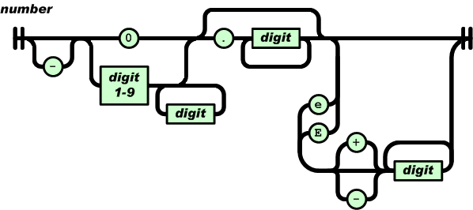

Ref for Image/Text: [JSON ORG](https://www.json.org/)

# Description of the Data Set Chosen

There are several JSON data sets are available from federal/state/county/city or other sources. We have selected the [accidental drug related deaths from 2012-2018 dataset](https://data.ct.gov/Health-and-Human-Services/Accidental-Drug-Related-Deaths-2012-2018/rybz-nyjw) from state of Connecticut. A “Y” value under the different substance columns indicates that particular substance was detected. Data are derived from an investigation by the Office of the Chief Medical Examiner which includes the toxicity report, death certificate, as well as a scene investigation.  
The dataset contains 5105 rows and 42 columns and each row is a Death. The data captures Date of the incident, Sex, Race, Age, Location Data, Resposible Drug, Cause of Death, Opiod or Not etc.

# Packages for Reading JSON Data

We have used jsonlite package to read JSON data. The package offers ﬂexible, robust, high performance tools for working with JSON in R and is particularly powerful for building pipelines and interacting with a web API. It reads JSON data and converts it to a R data type usually List or Data Frame which can be used for data manipulation and further computation. This is ideal for interacting with web APIs, or to build pipelines where data structures seamlessly flow in and out of R using JSON. The most useful functions are `fromJSON()` and `toJSON()`.

# Reading JSON File

### Download and Examine the JSON file

After we have downloaded the JSON file from the above mentioned link we have examined it in the firefox. The JSON has a metadata portion along with the data segment.

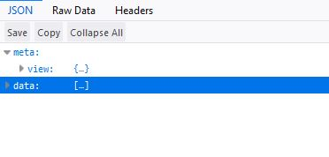

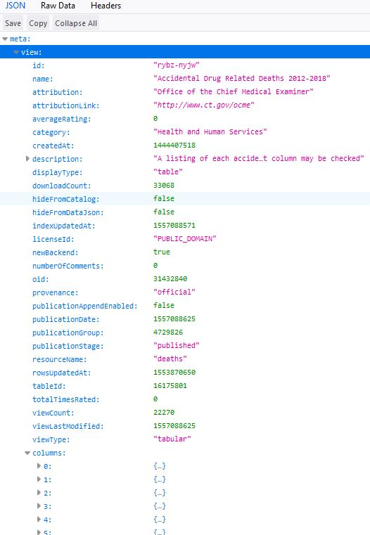

We have used the `jsonlite` package to read in the JSON file.

```r
library(jsonlite)
library(tidyverse)
library(gdata)
library(ggplot2)
myJSON <- fromJSON("./files/DrugOverdose.json")
class(myJSON)
```

```
## [1] "list"
```

Let’s examine the structure and attibutes a bit further.

```r
attributes(myJSON)
```

```
## $names
## [1] "meta" "data"
```

```r
attributes(myJSON[['meta']])
```

```
## $names
## [1] "view"
```

```r
attributes(myJSON[['meta']][['view']])
```

```
## $names
##  [1] "id"                       "name"
##  [3] "attribution"              "attributionLink"
##  [5] "averageRating"            "category"
##  [7] "createdAt"                "description"
##  [9] "displayType"              "downloadCount"
## [11] "hideFromCatalog"          "hideFromDataJson"
## [13] "indexUpdatedAt"           "licenseId"
## [15] "newBackend"               "numberOfComments"
## [17] "oid"                      "provenance"
## [19] "publicationAppendEnabled" "publicationDate"
## [21] "publicationGroup"         "publicationStage"
## [23] "resourceName"             "rowsUpdatedAt"
## [25] "tableId"                  "totalTimesRated"
## [27] "viewCount"                "viewLastModified"
## [29] "viewType"                 "columns"
## [31] "grants"                   "license"
## [33] "metadata"                 "owner"
## [35] "query"                    "rights"
## [37] "tableAuthor"              "tags"
## [39] "flags"
```

### Extract the column names.

```r
colNames <-myJSON[['meta']][['view']][['columns']]
colNames<- colNames[c(9:50),2]
colNames
```

```
##  [1] "ID"                  "Date"                "DateType"
##  [4] "Age"                 "Sex"                 "Race"
##  [7] "ResidenceCity"       "ResidenceCounty"     "ResidenceState"
## [10] "DeathCity"           "DeathCounty"         "Location"
## [13] "LocationifOther"     "DescriptionofInjury" "InjuryPlace"
## [16] "InjuryCity"          "InjuryCounty"        "InjuryState"
## [19] "COD"                 "OtherSignifican"     "Heroin"
## [22] "Cocaine"             "Fentanyl"            "FentanylAnalogue"
## [25] "Oxycodone"           "Oxymorphone"         "Ethanol"
## [28] "Hydrocodone"         "Benzodiazepine"      "Methadone"
## [31] "Amphet"              "Tramad"              "Morphine_NotHeroin"
## [34] "Hydromorphone"       "Other"               "OpiateNOS"
## [37] "AnyOpioid"           "MannerofDeath"       "DeathCityGeo"
## [40] "ResidenceCityGeo"    "InjuryCityGeo"       "Town Index"
```

### Extract the Data Portion

Let’s examine the data segment of the JSON file in the JSON editor/browser.

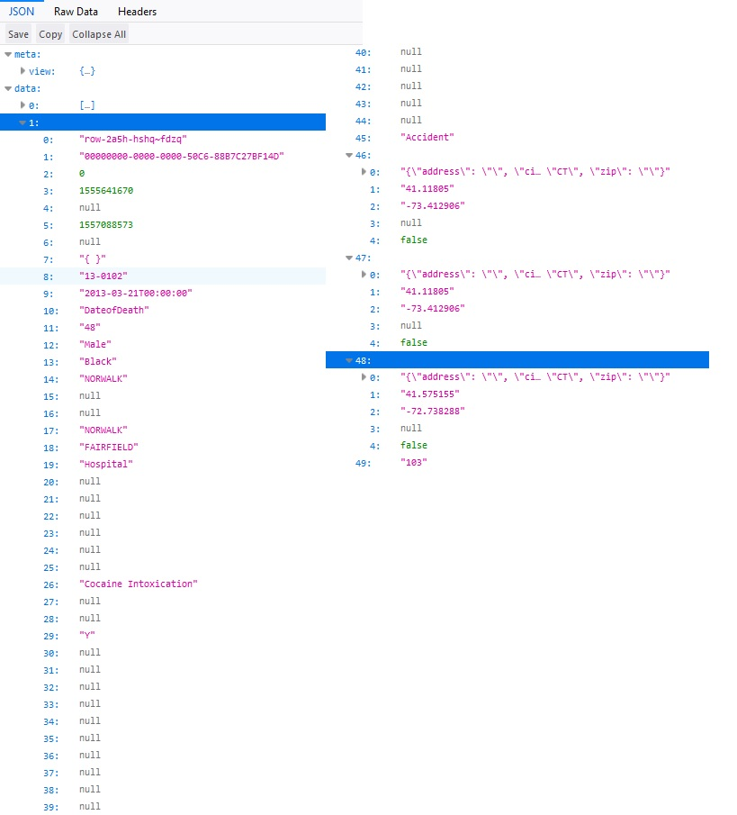

We can see the data portion of the JSON file is a nested list and let’s make sure the length of the top list matches the no of rows we have from the source page.

```r
myData <- myJSON[['data']]
length(myData)
```

```
## [1] 5105
```

### Generate Data Frame from JSON

This custom function reads the list data and convert that to a data frame and tibble. The DeathCityGeo, ResidenceCityGeo and InjuryCityGeo are nested list. The function reads the lattitude and longtitude from those nested lists.

```r
#Custom function to extract data
collectData<-function(var){
  sapply(myData, function(x) returnData(x, var))
}
returnData<-function(x, var){
  if(length(x[[var]]) > 1){
    return(trim(paste(x[[var]][[2]], x[[var]][[3]], sep = ",")))
  }
  else{
    if(!is.null( x[[var]])){
    return( trim(x[[var]]))
  }else{
    return(NA)
  }
  }
}
drugDF<-data.frame(sapply(9:50, collectData), stringsAsFactors=FALSE)
drugOverDoseTD <- tbl_df(drugDF)
colnames(drugOverDoseTD) <- colNames
drugOverDoseTD
```

```
## # A tibble: 5,105 x 42
##    ID    Date  DateType Age   Sex   Race  ResidenceCity ResidenceCounty
##    <chr> <chr> <chr>    <chr> <chr> <chr> <chr>         <chr>
##  1 14-0~ 2014~ DateRep~ <NA>  <NA>  <NA>  <NA>          <NA>
##  2 13-0~ 2013~ DateofD~ 48    Male  Black NORWALK       <NA>
##  3 16-0~ 2016~ DateofD~ 30    Fema~ White SANDY HOOK    FAIRFIELD
##  4 16-0~ 2016~ DateofD~ 23    Male  White RYE           WESTCHESTER
##  5 13-0~ 2013~ DateofD~ 22    Male  Asia~ FLUSHING      QUEENS
##  6 14-0~ 2014~ DateofD~ 23    Male  White BRISTOL       <NA>
##  7 12-0~ 2012~ DateofD~ 21    Fema~ White WEST HARTFORD HARTFORD
##  8 13-0~ 2013~ DateofD~ 40    Fema~ White HAMDEN        NEW HAVEN
##  9 12-0~ 2012~ DateofD~ 40    Male  White EAST HARTFORD HARTFORD
## 10 13-0~ 2013~ DateofD~ 50    Male  White MONTVILLE     NEW LONDON
## # ... with 5,095 more rows, and 34 more variables: ResidenceState <chr>,
## #   DeathCity <chr>, DeathCounty <chr>, Location <chr>,
## #   LocationifOther <chr>, DescriptionofInjury <chr>, InjuryPlace <chr>,
## #   InjuryCity <chr>, InjuryCounty <chr>, InjuryState <chr>, COD <chr>,
## #   OtherSignifican <chr>, Heroin <chr>, Cocaine <chr>, Fentanyl <chr>,
## #   FentanylAnalogue <chr>, Oxycodone <chr>, Oxymorphone <chr>,
## #   Ethanol <chr>, Hydrocodone <chr>, Benzodiazepine <chr>,
## #   Methadone <chr>, Amphet <chr>, Tramad <chr>, Morphine_NotHeroin <chr>,
## #   Hydromorphone <chr>, Other <chr>, OpiateNOS <chr>, AnyOpioid <chr>,
## #   MannerofDeath <chr>, DeathCityGeo <chr>, ResidenceCityGeo <chr>,
## #   InjuryCityGeo <chr>, `Town Index` <chr>
```

Convert the Age and Town Index to numeric and the date column to date type.

```r
drugOverDoseTD['Age'] <- as.numeric(drugOverDoseTD$Age)
drugOverDoseTD['Town Index'] <- as.numeric(drugOverDoseTD$`Town Index`)
drugOverDoseTD['Date'] <- as.Date(drugOverDoseTD$Date)
```

# Create New Variables

We have the Date and DateType column which has DateReported/DateofDeath. We can extract the Year from the date which can help us to summarize data by year if needed. Also we have another quantative column Age; and we can use that to create a categorical variable which may be usuful to analyze the affected ages.

```r
library(lubridate)
#Create the Year Variable
drugOverDoseTD['Year'] <- year(drugOverDoseTD$Date)
#Create Age Category Variable
drugOverDoseTD<- drugOverDoseTD %>% mutate(Age_Category = ifelse(Age < 18, 'Minor', ifelse(Age > 18 & Age <= 25, 'Age 18 to 25', ifelse(Age > 25 & Age <= 35, 'Age 26 to 35', ifelse(Age > 35 & Age <= 45, 'Age 36 to 45', ifelse(Age > 46 & Age <= 55, 'Age 46 to 55', ifelse(Age > 55 & Age <= 65, 'Age 56 to 65', 'More than 65')))))))
#Verify the results
head(drugOverDoseTD[, 43:44], n=10)
```

```
## # A tibble: 10 x 2
##     Year Age_Category
##    <dbl> <chr>
##  1  2014 <NA>
##  2  2013 Age 46 to 55
##  3  2016 Age 26 to 35
##  4  2016 Age 18 to 25
##  5  2013 Age 18 to 25
##  6  2014 Age 18 to 25
##  7  2012 Age 18 to 25
##  8  2013 Age 36 to 45
##  9  2012 Age 36 to 45
## 10  2013 Age 46 to 55
```

# Data Analysis

### Summarise data

#### Age Summary

Below table shows the summary of the reported ages. We can see the affected ages in a range as low as 14 and as high as 87 and the mean & median both are at around 42.

```r
library(knitr)
library(DT)
#Age Summary
datatable(enframe(round(summary(drugOverDoseTD$Age, na.rm = TRUE),2)), options = list(dom ="t"), caption = "Age Summary", rownames = FALSE)
```

| name | value |
| --- | --- |
| Min. | 14 |
| 1st Qu. | 32 |
| Median | 42 |
| Mean | 41.96 |
| 3rd Qu. | 52 |
| Max. | 87 |
| NA's | 3 |

#### Age Category Summary

Below table summarises the age category frequency summary from year 2012 to 2018 in 7 different levels. We can see there are 13 incidents involving Minors. Majority of the affected population are between age 26 to age 55.

```r
#Age Category Frequency
datatable(enframe(table(factor(drugOverDoseTD$Age_Category, levels = c("Minor",  "Age 18 to 25", "Age 26 to 35", "Age 36 to 45", "Age 46 to 55", "Age 56 to 65", "More than 65")))), options = list(dom ="t"), caption = "Age Category Frequency", rownames = FALSE)
```

| name | value |
| --- | --- |
| Minor | 13 |
| Age 18 to 25 | 477 |
| Age 26 to 35 | 1279 |
| Age 36 to 45 | 1201 |
| Age 46 to 55 | 1205 |
| Age 56 to 65 | 699 |
| More than 65 | 228 |

```r
#Year Vs Age Category Frequency
datatable(as.data.frame.matrix(table(drugOverDoseTD$Year, factor(drugOverDoseTD$Age_Category, levels = c("Minor",  "Age 18 to 25", "Age 26 to 35", "Age 36 to 45", "Age 46 to 55", "Age 56 to 65", "More than 65")))), options = list(dom ="t"), caption = "Year Vs Age category Frequency")
```

|  | Minor | Age 18 to 25 | Age 26 to 35 | Age 36 to 45 | Age 46 to 55 | Age 56 to 65 | More than 65 |
| --- | --- | --- | --- | --- | --- | --- | --- |
| 2012 | 3 | 37 | 91 | 79 | 89 | 33 | 23 |
| 2013 | 0 | 57 | 116 | 109 | 119 | 66 | 23 |
| 2014 | 2 | 49 | 140 | 144 | 143 | 48 | 31 |
| 2015 | 2 | 73 | 176 | 151 | 184 | 105 | 35 |
| 2016 | 1 | 80 | 236 | 214 | 219 | 132 | 35 |
| 2017 | 1 | 99 | 277 | 250 | 219 | 159 | 33 |
| 2018 | 4 | 82 | 242 | 254 | 232 | 156 | 48 |

Below table summarises Sex Vs Age category table. It shows no of accidents for each age category in each sex combining all year data from 2012 to 2018. We see for female the age category 46 to 55 has the highest count whereas man as the highest for 26 to 35.

```r
#create the Sex Vs Age category table
sexAgeTable <- table(drugOverDoseTD$Sex, factor(drugOverDoseTD$Age_Category, levels = c("Minor",  "Age 18 to 25", "Age 26 to 35", "Age 36 to 45", "Age 46 to 55", "Age 56 to 65", "More than 65")))
#Print the table
datatable(as.data.frame.matrix(sexAgeTable), options = list(dom ="t"), caption = "Sex Vs Age Category table")
```

|  | Minor | Age 18 to 25 | Age 26 to 35 | Age 36 to 45 | Age 46 to 55 | Age 56 to 65 | More than 65 |
| --- | --- | --- | --- | --- | --- | --- | --- |
| Female | 7 | 131 | 297 | 289 | 352 | 196 | 53 |
| Male | 6 | 346 | 982 | 910 | 853 | 502 | 174 |
| Unknown | 0 | 0 | 0 | 0 | 0 | 0 | 1 |

This is a 3 way table between Race, Sex and Age variables. It displays count and mean age for each Race and Sex.

```r
datatable(drugOverDoseTD %>% group_by(Race, Sex) %>% summarise(Count = n(), Mean_Age = round(mean(Age, na.rm = TRUE), 2)) %>% drop_na() %>% arrange(Mean_Age), options = list(dom ="t"), caption = "Race - Sex - Age Summary", rownames = FALSE)
```

| Race | Sex | Count | Mean_Age |
| --- | --- | --- | --- |
| Chinese | Male | 1 | 23 |
| Chinese | Female | 1 | 25 |
| Asian Indian | Female | 3 | 25.67 |
| Other | Female | 1 | 30 |
| Asian, Other | Male | 11 | 30.09 |
| Unknown | Female | 4 | 35.75 |
| Hispanic, Black | Female | 5 | 37 |
| Asian Indian | Male | 11 | 38.18 |
| Other | Male | 10 | 39.4 |
| Unknown | Male | 19 | 40.05 |

[output cut: 11 more lines]

#### Average Age Summary

In the next summary, we can see tha average age based on sex and race. We found that the average age for men was 42 and for women was 43. The interesting thing was that for unknown gender, the average age was 66. For the average age by race, we found that the Chinese had the lowest average age of 24 and Hawaiians had the highest average age of 58.

```r
#average age by gender
avgAgeSex<-drugOverDoseTD %>% group_by(Sex) %>% summarise(round(mean(Age),0))
colnames(avgAgeSex)[colnames(avgAgeSex) == "round(mean(Age), 0)"] <- "Average Age"
kable(avgAgeSex)
```

| Sex | Average Age |
| --- | --- |
| NA | NA |
| Female | 43 |
| Male | 42 |
| Unknown | 66 |

```r
#average age by race
avgAgeRace<-drugOverDoseTD %>% group_by(Race) %>% summarise(round(mean(Age),0))
colnames(avgAgeRace)[colnames(avgAgeRace) == "round(mean(Age), 0)"] <- "Average Age"
kable(avgAgeRace)
```

[output not shown]

```r
raceage<-table(drugOverDoseTD$Race, drugOverDoseTD$Age_Category)
kable(raceage)
```

|  | Age 18 to 25 | Age 26 to 35 | Age 36 to 45 | Age 46 to 55 | Age 56 to 65 | Minor | More than 65 |
| --- | --- | --- | --- | --- | --- | --- | --- |
| Asian Indian | 2 | 6 | 2 | 2 | 1 | 0 | 1 |
| Asian, Other | 4 | 7 | 3 | 3 | 0 | 0 | 1 |
| Black | 23 | 67 | 82 | 134 | 98 | 0 | 29 |
| Chinese | 2 | 0 | 0 | 0 | 0 | 0 | 0 |
| Hawaiian | 0 | 0 | 0 | 0 | 1 | 0 | 0 |
| Hispanic, Black | 2 | 6 | 6 | 6 | 3 | 0 | 1 |
| Hispanic, White | 42 | 117 | 171 | 149 | 58 | 1 | 23 |
| Native American, Other | 0 | 0 | 1 | 0 | 0 | 0 | 0 |
| Other | 1 | 5 | 2 | 1 | 2 | 0 | 0 |
| Unknown | 6 | 5 | 2 | 7 | 3 | 0 | 0 |
| White | 395 | 1064 | 929 | 900 | 532 | 12 | 172 |

```r
sexyear<-table(drugOverDoseTD$Sex, drugOverDoseTD$Year)
kable(sexyear)
```

|  | 2012 | 2013 | 2014 | 2015 | 2016 | 2017 | 2018 |
| --- | --- | --- | --- | --- | --- | --- | --- |
| Female | 97 | 140 | 167 | 190 | 232 | 260 | 239 |
| Male | 258 | 350 | 390 | 536 | 685 | 777 | 776 |
| Unknown | 0 | 0 | 0 | 0 | 0 | 0 | 1 |

### Visualise data

Let’s start visualising no of accidents per year from 2012 to 2018. We see a clear incresing trend from 2012 to 2017 and a slight decrease in 2018.

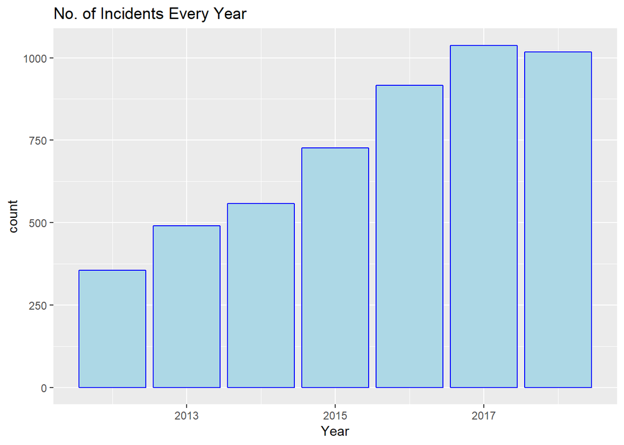

```r
library(ggplot2)
#Plot Incident Count for each Year
g<- ggplot(data = drugOverDoseTD , aes(x = Year))
g+geom_bar(color = "blue", fill="light blue") + labs(title = "No. of Incidents Every Year")
```

This bar plot display the no of accidents for each drug combining all years. It is clear Heroin is most responsible followed by Fentanyl for Accidental Drug Related Deaths from 2012 to 2018.

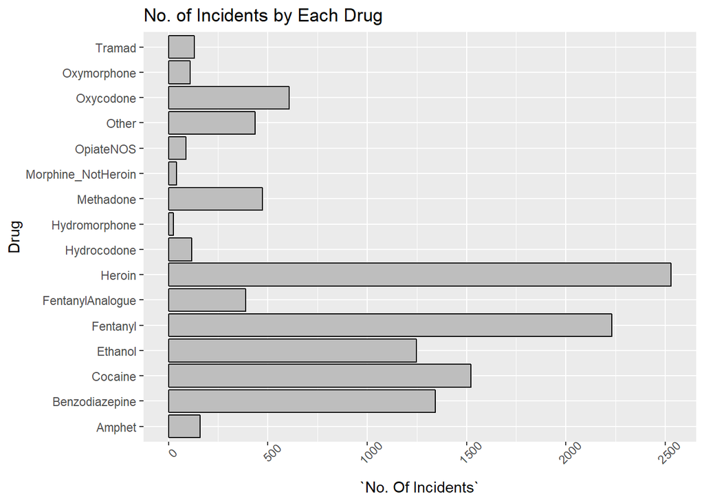

```r
#Plot Different Drug Vs Overdose Count
drugCount <- apply(X= select(drugOverDoseTD, Heroin:OpiateNOS), MARGIN = 2, FUN = function(y) {
     temp <- length(y[!is.na(y)])
      names(temp) <- "Overdose Counts"
      temp
       })
drugCount<- tibble::enframe(drugCount)
names(drugCount) <- c("Drug", "No. Of Incidents")
p<-ggplot(data=drugCount, aes(x=Drug, y= `No. Of Incidents`)) +
  geom_bar(stat="identity", color = "black", fill = "grey") + theme(axis.text.x = element_text(angle = 45)) + coord_flip() + labs(title = "No. of Incidents by Each Drug")

p
```

This line plot displays No. of Incidents by Each Drug from 2012-2018. We can see couple of drugs are same over the years but most of them have increased. Specially there is a spike in increase for Fentanyl. Heroine has increased from 2012 to 2016 but it declined steadily in 2017 and 2018.

```r
#Plot Different Drug Vs Overdose Count for each Year
#Take Year and the different drugs
drugYearCount<- drugOverDoseTD[, c(43, 21:36)]
#Make it a long Tidy Data Set
drugYearCount<- drugYearCount %>% gather(key = Drug, value = 'Y/N', 2:17)
#Remove NAs
drugYearCount<- drugYearCount[complete.cases(drugYearCount) , ]
#make tibble
drugYearCount <- tbl_df(as.data.frame(drugYearCount %>% group_by(Year, Drug) %>% summarise(Count = n())))
#Verify the data
datatable(drugYearCount, options = list(dom ="t"), caption = "Year and Drug", rownames = FALSE)
```

| Year | Drug | Count |
| --- | --- | --- |
| 2012 | Amphet | 7 |
| 2012 | Benzodiazepine | 49 |
| 2012 | Cocaine | 105 |
| 2012 | Ethanol | 61 |
| 2012 | Fentanyl | 14 |
| 2012 | Heroin | 174 |
| 2012 | Hydrocodone | 15 |
| 2012 | Methadone | 33 |
| 2012 | Other | 39 |
| 2012 | Oxycodone | 70 |

[output cut: 86 more lines]

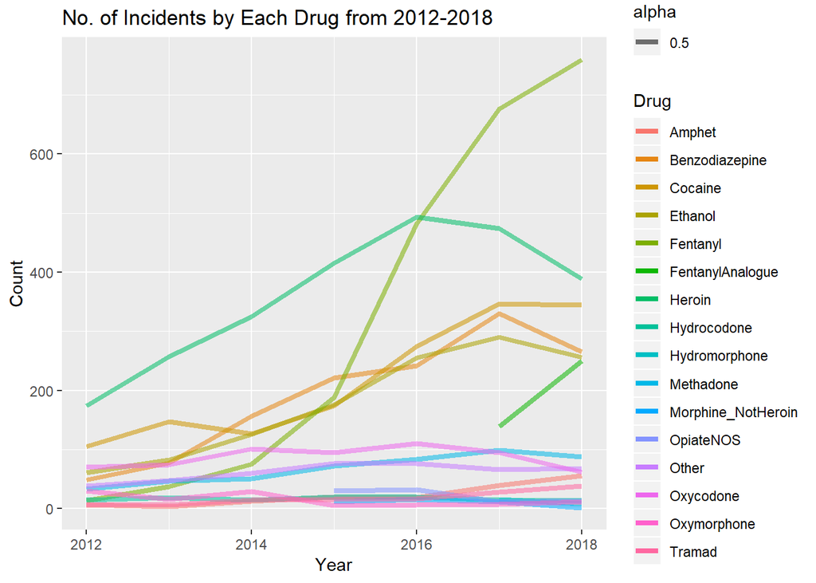

```r
g<- ggplot(data = drugYearCount, aes(x = Year, y = Count))
g + geom_line(aes(color = Drug, alpha = 0.5), lwd =1.5) + labs(title = "No. of Incidents by Each Drug from 2012-2018 ")
```

This barplot shows the distribution of ages combining all years.

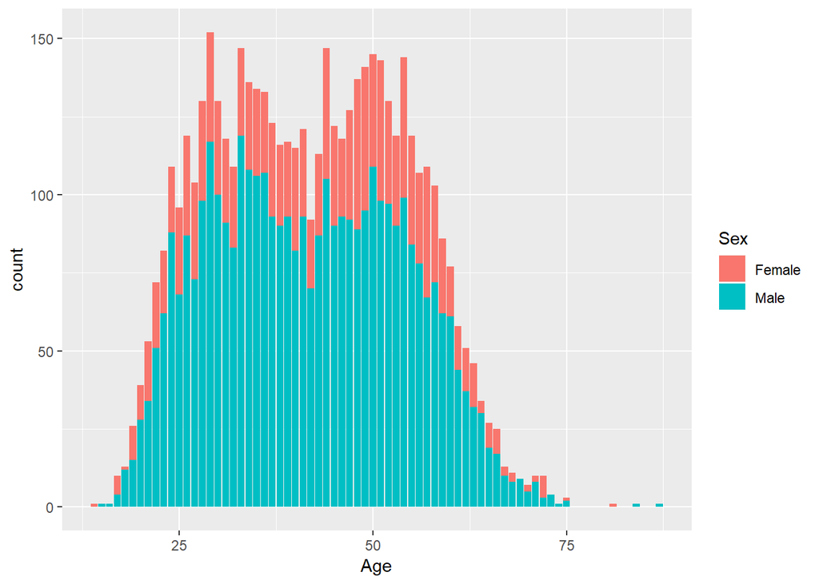

```r
#Plot Year with Age and Sex
g<- ggplot(data = drugOverDoseTD %>% select(Age, Sex) %>% drop_na() %>% filter(Sex != 'Unknown'), aes(x = Age, fill = Sex))
g + geom_bar()
```

This line plot displays the no of incidents over the year for both sex Male and Female. For female the incidents has a steady rise from 2012 to 2017 and a slight decrease in 2018. For male it also has a steady rise from 2012 to 2014 but has a sharp rise from 2014 to 2017 and stabilizes in 2018.

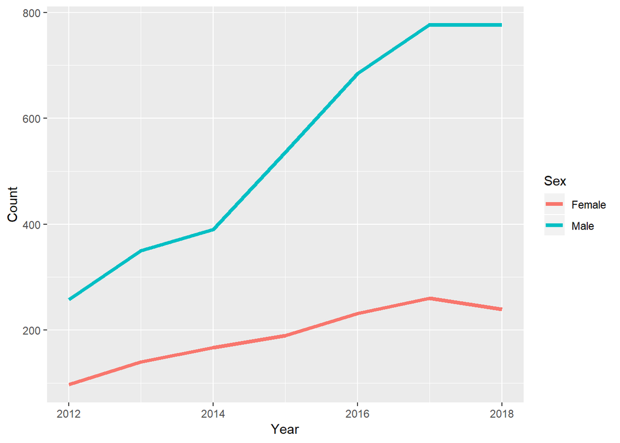

```r
# Year and Sex Line plot
drugYearSexCount <- as.data.frame(drugOverDoseTD %>% group_by(Year, Sex) %>% summarise(Count = n()))
drugYearSexCount<- drugYearSexCount[complete.cases(drugYearSexCount) & trim(drugYearSexCount$Sex) != 'Unknown', ]
g<- ggplot(data = drugYearSexCount, aes(x = Year, y = Count))
g + geom_line(aes(color = Sex), lwd =1.5)
```

The dataset also captures whether the drug responsible is opioid or not and we don’t have this data before 2015. The line plot clearly shows we have a steep and steady rise from 2015 to 2016 and 2016 to 2016 respectively.

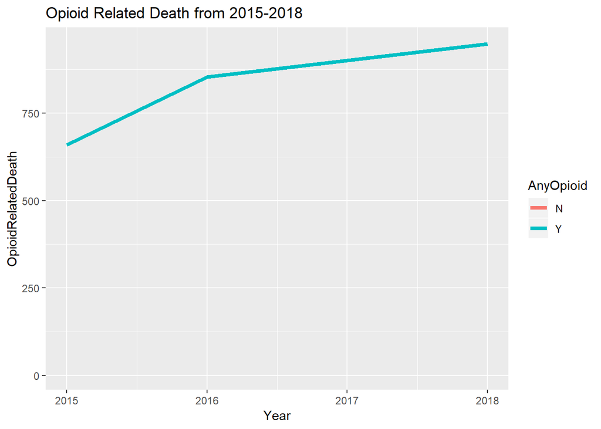

```r
drugOpioid <- drugOverDoseTD %>% group_by(Year, AnyOpioid) %>% summarise(OpioidRelatedDeath = n()) %>% drop_na()
g<- ggplot(data = drugOpioid, aes(x = Year, y = OpioidRelatedDeath))
g + geom_line(aes(color = AnyOpioid), lwd =1.5) + labs(title = "Opioid Related Death from 2015-2018 ")
```